# MNIST in Keras with R

The MNIST database (Modified National Institute of Standards and Technology database) is a large database of labelled handwritten digits.

The MNIST database is also widely used for training and testing in the field of machine learning, and is considered the ‘Hello World’ task of image processing.

## Keras

We will be using the `Keras` library to construct the model. Keras is much more user-friendly than TensorFlow, and we will be able to push away some of the difficult parts to `Keras` to solve so we make fewer errors. Keras also comes with better defaults, so our models should have fewer simple errors (e.g. forgetting to add biases) overall.

### Load the MNIST Dataset

```r
library(keras)

mnist <- dataset_mnist()
x_train <- mnist$train$x
y_train <- mnist$train$y
x_test <- mnist$test$x
y_test <- mnist$test$y

image_width <- 28
image_size <- image_width ** 2
```

### Visualise the data

Lets have a go at seeing the first few images in the dataset.

```r
library(tidyverse)
library(rbokeh)

rotate <- function(x) t(apply(x, 2, rev))

reshape_image <- function(x) {
  x %>%
    matrix(nrow = image_width) %>%
    rotate()
}

image_data <- tibble(
  input = lapply(seq(1,nrow(x_train)), function(i) rotate(x_train[i,1:image_width, 1:image_width])),
  target = y_train) %>%
  group_by(target) %>%
  do(sample_n(., size = 10)) %>%
  ungroup()

# group a 10x10 collection of images together
imgs <- image_data %>%
  group_by(target) %>%
  summarise(row = list(Reduce(cbind, input))) %>%
  do(as_tibble(Reduce(rbind, .$row))) %>%
  as.matrix()

params = list(xgrid = FALSE, ygrid = FALSE, xaxes = FALSE, yaxes = FALSE, tools = NULL)
black_and_white <- colorRampPalette(c('white', 'black'))(255)

plot_image <- function(x, fig_params = list(NULL), img_params = list(NULL)) {
  # create the plot
  fig = do.call(figure, fig_params)
  do.call(ly_image, append(list(fig, x), img_params))
}

plot_image(imgs, fig_params = params, img_params = list(palette = black_and_white))
```

[interactive chart not shown]

## Preprocess Data

```r
# reshape data
dim(x_train) <- c(nrow(x_train), image_size)
dim(x_test) <- c(nrow(x_test), image_size)

# Transform RGB values into [0,1] range
x_train <- x_train / 255
x_test <- x_test / 255

y_train <- to_categorical(y_train, 10)
y_test <- to_categorical(y_test, 10)
```

## Convolutional Network

We reshape the training examples. This time the images need to be input as 2d images.

```r
# Redefine  dimension of train/test inputs
dim(x_train) <- c(nrow(x_train), image_width, image_width, 1)
dim(x_test) <- c(nrow(x_test), image_width, image_width, 1)
```

Next we define some hyperparameters.

```r
# Define conv_model -----------------------------------------------------------
input_shape <- c(image_width, image_width, 1)
num_classes <- 10
batch_size <- 128
epochs = 30
```

### Define the model

```r
model_loaded = FALSE
if (file.exists("models/conv_model.hdf5")) {
  conv_model = keras::load_model_hdf5("models/conv_model.hdf5")
  model_loaded = TRUE

} else {
  conv_model <- keras_model_sequential()
  conv_model %>%
    layer_conv_2d(filters = 128, kernel_size = c(8,8), activation = 'relu',
                  input_shape = input_shape) %>%
    layer_max_pooling_2d(pool_size = c(4, 4)) %>%
    layer_conv_2d(filters = 128, kernel_size = c(4,4), activation = 'relu') %>%
    layer_max_pooling_2d(pool_size = c(2, 2)) %>%
    layer_flatten() %>%
    layer_dense(units = 128, activation = 'relu') %>%
    layer_dropout(rate = 0.5) %>%
    layer_dense(units = 256, activation = 'relu') %>%
    layer_dropout(rate = 0.5) %>%
    layer_dense(units = 256, activation = 'relu') %>%
    layer_dropout(rate = 0.5) %>%
    layer_dense(units = num_classes, activation = 'softmax')

  # Compile conv_model
  conv_model %>% compile(
    loss = loss_categorical_crossentropy,
    optimizer = optimizer_adam(lr = 0.0001),
    metrics = c('accuracy')
  )
}
```

```r
conv_model
```

```
## Model
## ___________________________________________________________________________
## Layer (type)                     Output Shape                  Param #
## ===========================================================================
## conv2d_1 (Conv2D)                (None, 21, 21, 128)           8320
## ___________________________________________________________________________
## max_pooling2d_1 (MaxPooling2D)   (None, 5, 5, 128)             0
## ___________________________________________________________________________
## conv2d_2 (Conv2D)                (None, 2, 2, 128)             262272
## ___________________________________________________________________________
## max_pooling2d_2 (MaxPooling2D)   (None, 1, 1, 128)             0
## ___________________________________________________________________________
## flatten_1 (Flatten)              (None, 128)                   0
## ___________________________________________________________________________
## dense_1 (Dense)                  (None, 128)                   16512
## ___________________________________________________________________________
## dropout_1 (Dropout)              (None, 128)                   0
## ___________________________________________________________________________
## dense_2 (Dense)                  (None, 256)                   33024
## ___________________________________________________________________________
## dropout_2 (Dropout)              (None, 256)                   0
## ___________________________________________________________________________
## dense_3 (Dense)                  (None, 256)                   65792
## ___________________________________________________________________________
## dropout_3 (Dropout)              (None, 256)                   0
## ___________________________________________________________________________
## dense_4 (Dense)                  (None, 10)                    2570
## ===========================================================================
## Total params: 388,490
## Trainable params: 388,490
## Non-trainable params: 0
## ___________________________________________________________________________
```

## Train the model

```r
if (!model_loaded) {
  # Train & Evaluate -------------------------------------------------------
  conv_history <- conv_model %>% fit(
    x_train, y_train,
    batch_size = batch_size,
    epochs = epochs,
    verbose = 1,
    validation_data = list(x_test, y_test),
    callbacks = callback_tensorboard(
      log_dir = "logs", write_grads = TRUE, write_images = TRUE)
  )
}
if (!model_loaded) {
  keras::save_model_hdf5(conv_model, "models/conv_model.hdf5")
}
```

```r
scores <- conv_model %>% evaluate(
  x_test, y_test, verbose = 0
)

# Output metrics
cat('Test loss:', scores[[1]], '\n')
```

```
## Test loss: 0.03207035
```

```r
cat('Test accuracy:', scores[[2]], '\n')
```

```
## Test accuracy: 0.9925
```

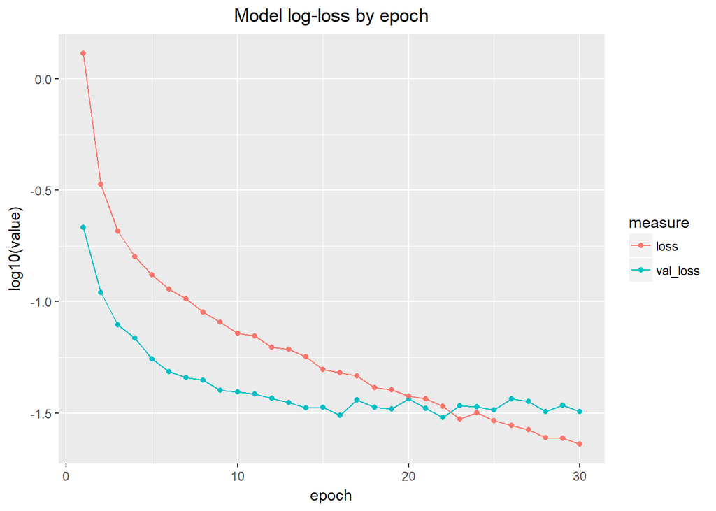

```r
if (!model_loaded) {
  conv_metrics <- as_tibble(conv_history$metrics) %>%
    mutate(epoch = seq(nrow(.))) %>%
    gather(val_loss, val_acc, loss, acc, key = "measure", value = "value")

  write_csv(conv_metrics, "models/conv_metrics.csv")
} else {
  conv_metrics = read_csv("models/conv_metrics.csv")
}
conv_metrics %>%
  filter(!(measure %in% c('acc', 'val_acc'))) %>%
  ggplot(aes(x = epoch, y = log10(value), group = measure, color = measure)) +
  geom_line() +
  geom_point() +
  ggtitle("Model log-loss by epoch") +
  theme(plot.title = element_text(hjust = 0.5))
```

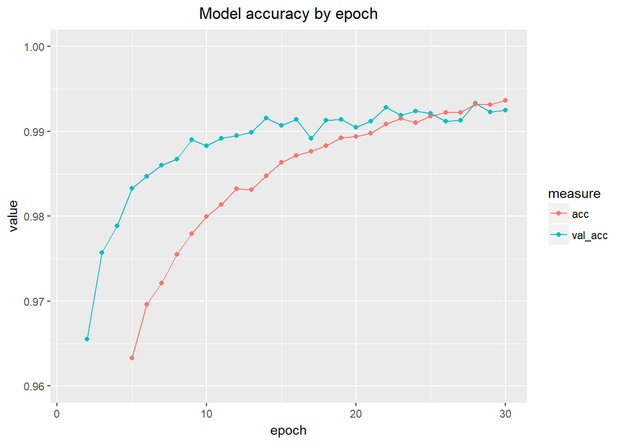

```r
conv_metrics %>%
  filter(!(measure %in% c('loss', 'val_loss'))) %>%
  ggplot(aes(x = epoch, y = value, group = measure, color = measure)) +
  geom_line() +
  geom_point() +
  scale_y_continuous(limits = c(0.96, 1)) +
  ggtitle("Model accuracy by epoch") +
  theme(plot.title = element_text(hjust = 0.5))
```

```r
calculate_preds <- function(model, x_test) {

  entropy <- function(p) - sum(ifelse(p > 0, p * log(p), 0))

  preds <- model %>%
    predict_proba(x_test) %>%
    as_tibble()

  colnames(preds) <- 0:9

  preds <- tibble(
        class   = apply(preds,  1, which.max) - 1,
        target  = apply(y_test, 1, which.max) - 1,
        entropy = apply(preds,  1, entropy),
        image   = lapply(1:nrow(x_test),
                         function(i) reshape_image(x_test[i, 1:image_width, 1:image_width, 1]))) %>%
    mutate(correct = class == target)

  return(preds)
}
conv_preds <- calculate_preds(conv_model, x_test)
conv_preds
```

```
## # A tibble: 10,000 x 5
##    class target      entropy           image correct
##    <dbl>  <dbl>        <dbl>          <list>   <lgl>
##  1     7      7 1.295008e-07 <dbl [28 x 28]>    TRUE
##  2     2      2 3.326544e-06 <dbl [28 x 28]>    TRUE
##  3     1      1 1.502391e-05 <dbl [28 x 28]>    TRUE
##  4     0      0 1.014002e-05 <dbl [28 x 28]>    TRUE
##  5     4      4 8.411518e-06 <dbl [28 x 28]>    TRUE
##  6     1      1 3.304874e-07 <dbl [28 x 28]>    TRUE
##  7     4      4 6.833006e-04 <dbl [28 x 28]>    TRUE
##  8     9      9 5.227503e-04 <dbl [28 x 28]>    TRUE
##  9     5      5 4.744943e-05 <dbl [28 x 28]>    TRUE
## 10     9      9 1.051392e-05 <dbl [28 x 28]>    TRUE
## # ... with 9,990 more rows
```

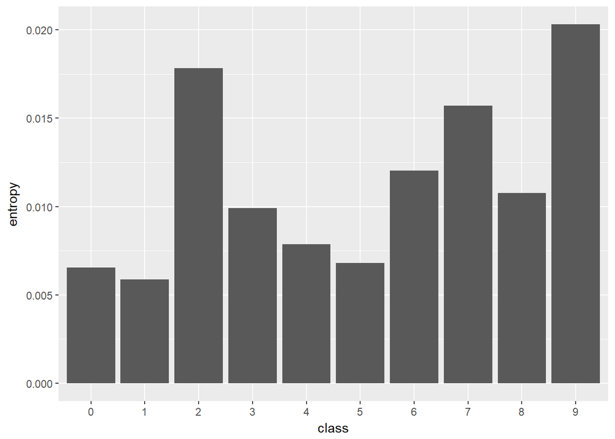

```r
plot_preds <- function(preds) {
  preds %>%
  group_by(class) %>%
  summarise(entropy = mean(entropy)) %>%
  mutate(class = as.character(class)) %>%
  ggplot(aes(x = class, y = entropy)) +
  geom_bar(stat = 'identity')
}

plot_preds(conv_preds)
```

```r
plot_conf_matrix <- function(preds) {
  preds %>%
    group_by(class, target) %>%
    summarise(best_image = image[which.min(entropy)], count = n()) %>%
    full_join(tibble(class = Reduce(c, lapply(seq(0, 9), function(x) rep(x, 10))),
        target = rep(seq(0, 9), 10)),
      by = c('class', 'target')) %>%
    mutate(count = ifelse(is.na(count), 0, count)) %>%
    mutate(best_image = ifelse(sapply(best_image, function(x) length(x) == 0),
      list(matrix(as.integer(rep(0, image_size)), nrow = image_width)),
      best_image)) %>%
    mutate(weighted_image = mapply(
      function(c, img) list(c * img), c = count, img = best_image)) %>%
    arrange(desc(class), desc(target)) %>%
    summarise(row = list(Reduce(cbind, weighted_image))) %>%
    do(as_tibble(Reduce(rbind, .$row))) %>%
    as.matrix() %>%
    log1p() %>%
    plot_image(fig_params = params,
               img_params = list(palette = colorRampPalette(c('dark blue', 'green', 'yellow', 'orange', 'dark red'))(100)))
}

plot_conf_matrix(conv_preds)
```

[interactive chart not shown]